# Regression diagnostics in Python

When we fit a linear regression model to a particular data set, many problems may occur. Most common among these are the following {cite:p}`James2021`:

1. Outliers and high-leverage points
2. Non-linearity of the response-predictor relationship
3. Non-constant variance of error terms (heteroscedasticity)
4. Non-normally distributed errors
5. Correlation of error terms
6. Collinearity

## Python setup

```python
import numpy as np
import pandas as pd
from patsy import dmatrices

from statsmodels.compat import lzip
import statsmodels.api as sm
from statsmodels.formula.api import ols
from statsmodels.stats.outliers_influence import variance_inflation_factor

import matplotlib.pyplot as plt
import seaborn as sns

%matplotlib inline
plt.rc("figure", figsize=(16, 8))
plt.rc("font", size=14)
```

## Import data

We use the function `.datasets.get_rdataset` to load the dataset from the [Rdatasets package](https://vincentarelbundock.github.io/Rdatasets/).

```python
# import data
df = sm.datasets.get_rdataset("Duncan", "carData", cache=True).data
```

```python
# show head of DataFrame
df.head()
```

|  | type | income | education | prestige |
| --- | --- | --- | --- | --- |
| accountant | prof | 62 | 86 | 82 |
| pilot | prof | 72 | 76 | 83 |
| architect | prof | 75 | 92 | 90 |
| author | prof | 55 | 90 | 76 |
| chemist | prof | 64 | 86 | 90 |

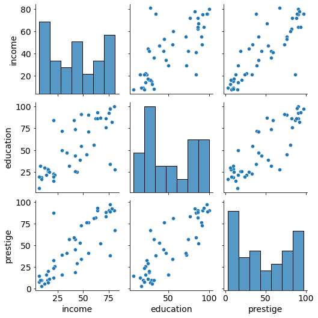

```python
# plot numerical data as pairs
sns.pairplot(df);
```

Findings:

- Positive association between prestige and eduction as well as between prestige and income
- Relationships seem to be linear in both cases.

## Model

```python
# estimate the model and save it as lm (linear model)
lm = ols("prestige ~ income + education", data=df).fit()
```

```python
# print regression results
print(lm.summary())
```

```
                            OLS Regression Results
==============================================================================
Dep. Variable:               prestige   R-squared:                       0.828
Model:                            OLS   Adj. R-squared:                  0.820
Method:                 Least Squares   F-statistic:                     101.2
Date:                Mon, 22 Nov 2021   Prob (F-statistic):           8.65e-17
Time:                        13:16:19   Log-Likelihood:                -178.98
No. Observations:                  45   AIC:                             364.0
Df Residuals:                      42   BIC:                             369.4
Df Model:                           2
Covariance Type:            nonrobust
==============================================================================
                 coef    std err          t      P>|t|      [0.025      0.975]
------------------------------------------------------------------------------
Intercept     -6.0647      4.272     -1.420      0.163     -14.686       2.556
income         0.5987      0.120      5.003      0.000       0.357       0.840
education      0.5458      0.098      5.555      0.000       0.348       0.744
==============================================================================
Omnibus:                        1.279   Durbin-Watson:                   1.458
Prob(Omnibus):                  0.528   Jarque-Bera (JB):                0.520
Skew:                           0.155   Prob(JB):                        0.771
Kurtosis:                       3.426   Cond. No.                         163.
==============================================================================

Notes:
[1] Standard Errors assume that the covariance matrix of the errors is correctly specified.
```

# Regression diagnostics

## Outliers and high-leverage points

In a regression analysis, single observations can have a strong influence on the results of the model.

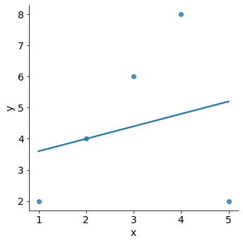

```python
# HIDE CODE
df_outlier = pd.DataFrame(
        { 'observation': pd.Categorical([ "A", "B", "C", "D", "E" ]),
          'x': np.array([1, 2, 3, 4, 5],dtype='int32'),
          'y': np.array([2, 4, 6, 8, 2],dtype='int32')}
        )

sns.lmplot(x="x", y="y", data=df_outlier, ci=False);
```

We can spot outliers by using graphs like the scatterplot above.

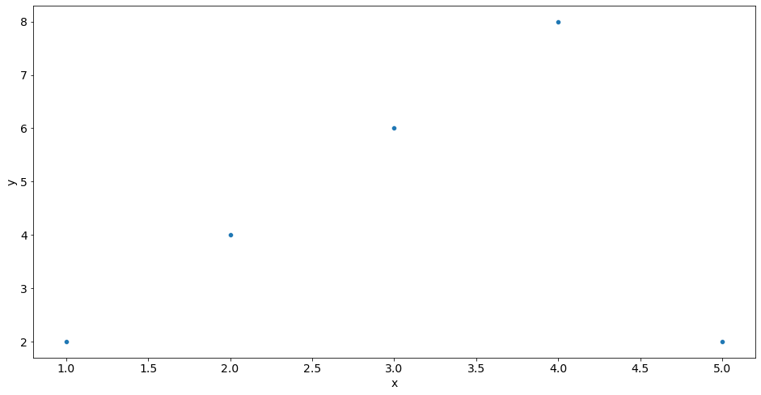

```python
sns.scatterplot(x='x', y='y', data=df_outlier);
```

We just saw that outliers are observations for which the response $y_i$ is unusual given the predictor $x_i$.

In contrast, observations with high **leverage** have an unusual value for $x_i$.

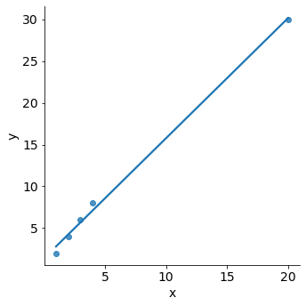

```python
# HIDE CODE
df_leverage = pd.DataFrame(
        { 'observation': pd.Categorical([ "A", "B", "C", "D", "E" ]),
          'x': np.array([1, 2, 3, 4, 20],dtype='int32'),
          'y': np.array([2, 4, 6, 8, 30],dtype='int32')}
        )

sns.lmplot(x="x", y="y", data=df_leverage, ci=False);
```

Again, we could use simple graphs to identify unusual observations.

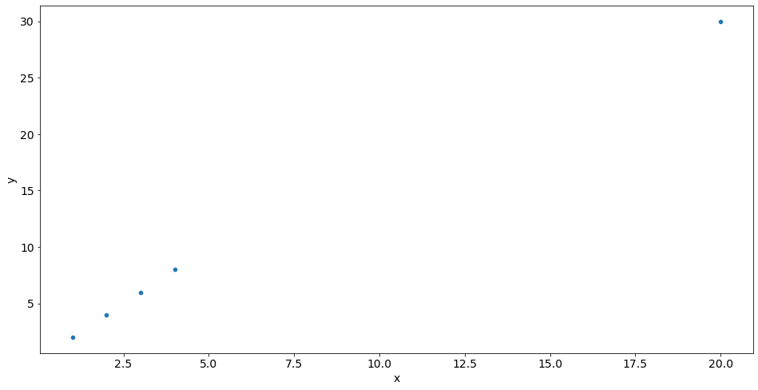

```python
sns.scatterplot(x='x', y='y', data=df_leverage);
```

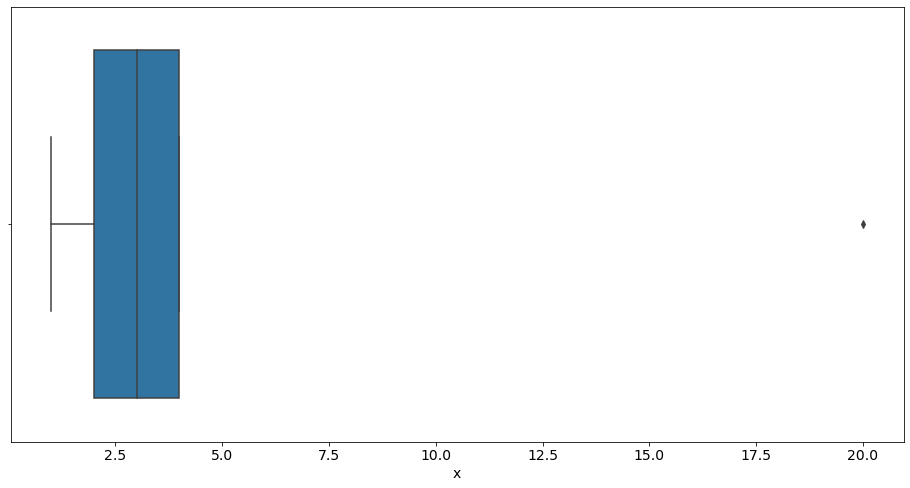

```python
sns.boxplot(x='x', data=df_leverage);
```

### Influence plots

> Influence plots are used to identify influential data points.

> They depend on both the residual and leverage i.e they take into account both the $x$ value and $y$ value of the observation.

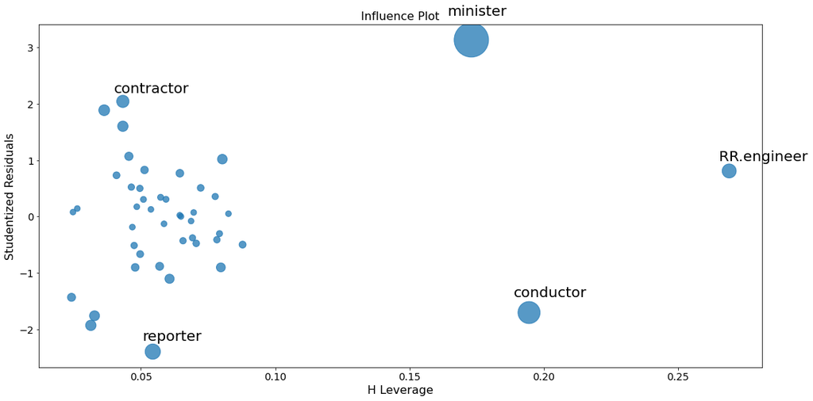

```python
fig = sm.graphics.influence_plot(lm, criterion="cooks")
fig.tight_layout(pad=1.0)
```

In addition to our plot, we can use the function `.get_influence()` to assess the influence of each observation and compare them to the cricital Cook's distance :

```python
# obtain Cook's distance
lm_cooksd = lm.get_influence().cooks_distance[0]

# get length of df to obtain n
n = len(df["income"])

# calculate critical d
critical_d = 4/n
print('Critical Cooks distance:', critical_d)

# identification of potential outliers with leverage
out_d = lm_cooksd > critical_d

# output potential outliers with leverage
print(df.index[out_d], "\n",
    lm_cooksd[out_d])
```

```
Critical Cooks distance: 0.08888888888888889
Index(['minister', 'reporter', 'conductor'], dtype='object')
 [0.56637974 0.09898456 0.22364122]
```

### Solutions

If you have unusual observations in your data (unusual depends on your use case and domain knowledge) here some approaches to deal with them:

1. **Drop** the identified unusual observations.
2. Analyse your data with **robust methods** like bootstrapping (sampling with replacement).
3. **Trim** the data (delete a certain amount of scores from the extremes)
4. **Windsorizing** (substitute outliers with the highest value that isn’t an outlier)
5. **Transform** the data (by applying a mathematical function to scores - like a log transformation to reduce positive skew).

## Non-linearity and heteroscedasticity

### Partial Regression Plots

With partial regression plots you can:

1. Investigate the relationship between a dependent and independent variables conditional on other independent varibales.
2. Identify the effects of the individual data values on the estimation of a coefficient.
3. Investigate violations of underlying assumptions such as linearity and homoscedasticity.

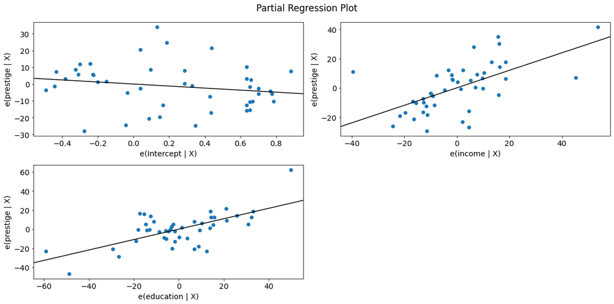

```python
fig = sm.graphics.plot_partregress_grid(lm)
fig.tight_layout(pad=1.0)
```

We observe a positive relationship between prestige and income as well as between prestige and education. The relationship seems to be linear in both cases.

Next, let's take a closer look at the observations.

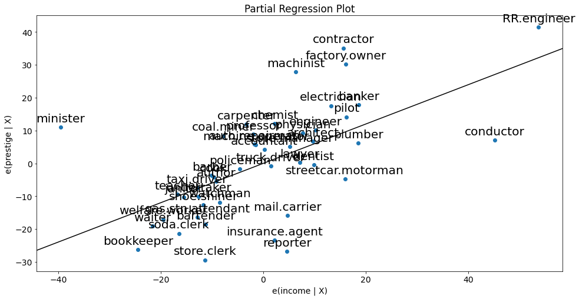

```python
sm.graphics.plot_partregress(
                             endog='prestige', # response
                             exog_i='income', # variable of interest
                             exog_others=['education'], # other predictors
                             data=df,  # dataframe
                             obs_labels=True # show labels
                             );
```

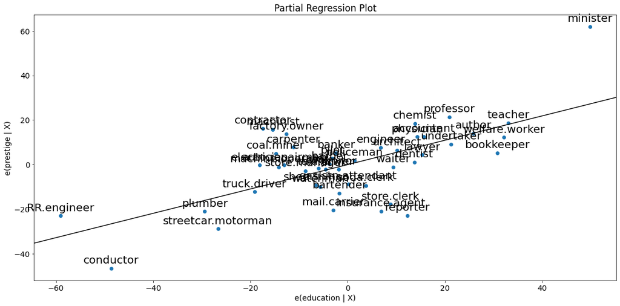

```python
# same plot for education
fig = sm.graphics.plot_partregress("prestige", "education", ["income"], data=df)
fig.tight_layout(pad=1.0)
```

```python
# make a subset and flag as TRUE if index doesn't contain ...
subset = ~df.index.isin(["conductor", "minister", "reporter"])

print(df.index, "\n", subset)
```

```
Index(['accountant', 'pilot', 'architect', 'author', 'chemist', 'minister',
       'professor', 'dentist', 'reporter', 'engineer', 'undertaker', 'lawyer',
       'physician', 'welfare.worker', 'teacher', 'conductor', 'contractor',
       'factory.owner', 'store.manager', 'banker', 'bookkeeper',
       'mail.carrier', 'insurance.agent', 'store.clerk', 'carpenter',
       'electrician', 'RR.engineer', 'machinist', 'auto.repairman', 'plumber',
       'gas.stn.attendant', 'coal.miner', 'streetcar.motorman', 'taxi.driver',
       'truck.driver', 'machine.operator', 'barber', 'bartender',
       'shoe.shiner', 'cook', 'soda.clerk', 'watchman', 'janitor', 'policeman',
       'waiter'],
      dtype='object')
 [ True  True  True  True  True False  True  True False  True  True  True
  True  True  True False  True  True  True  True  True  True  True  True
  True  True  True  True  True  True  True  True  True  True  True  True
  True  True  True  True  True  True  True  True  True]
```

```python
# compute regression without influential cases
lm2 = ols("prestige ~ income + education", data=df, subset=subset).fit()

print(lm2.summary())
```

```
                            OLS Regression Results
==============================================================================
Dep. Variable:               prestige   R-squared:                       0.897
Model:                            OLS   Adj. R-squared:                  0.891
Method:                 Least Squares   F-statistic:                     169.0
Date:                Mon, 22 Nov 2021   Prob (F-statistic):           6.13e-20
Time:                        13:16:21   Log-Likelihood:                -157.02
No. Observations:                  42   AIC:                             320.0
Df Residuals:                      39   BIC:                             325.2
Df Model:                           2
Covariance Type:            nonrobust
==============================================================================
                 coef    std err          t      P>|t|      [0.025      0.975]
------------------------------------------------------------------------------
Intercept     -7.2414      3.391     -2.136      0.039     -14.099      -0.383
income         0.8773      0.113      7.775      0.000       0.649       1.106
education      0.3538      0.092      3.861      0.000       0.168       0.539
==============================================================================
Omnibus:                        1.483   Durbin-Watson:                   1.577
Prob(Omnibus):                  0.476   Jarque-Bera (JB):                0.744
Skew:                          -0.291   Prob(JB):                        0.689
Kurtosis:                       3.293   Cond. No.                         156.
==============================================================================

Notes:
[1] Standard Errors assume that the covariance matrix of the errors is correctly specified.
```

Dropping the influential cases confirms our believe. The new regression model without the influential cases is superior to the initial one. To see this, compare the regression summary above with our initial summary (e.g., see $R^2$, adjusted $R^2$ and the F-statistic).

### CCPR plots

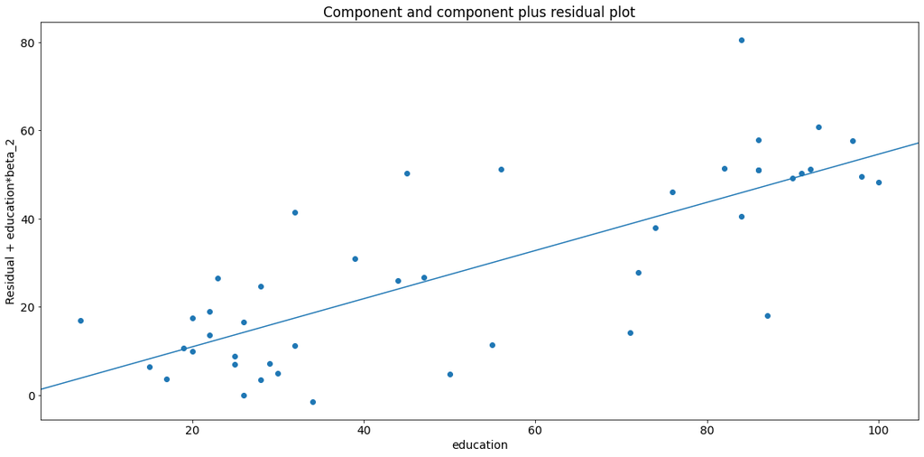

```python
fig = sm.graphics.plot_ccpr(lm, "education")
fig.tight_layout(pad=1.0)
```

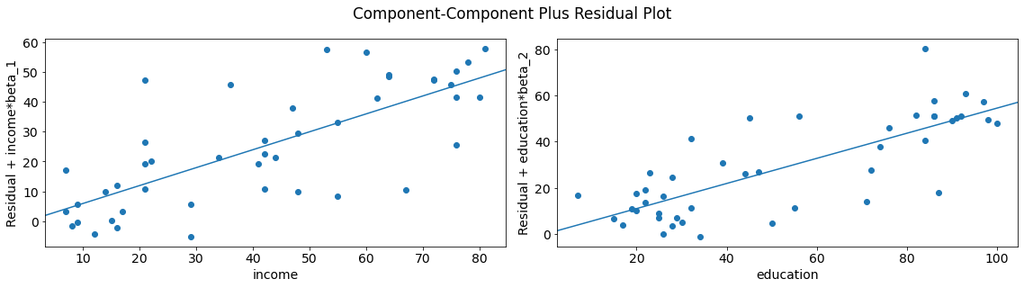

```python
fig = sm.graphics.plot_ccpr_grid(lm)
fig.tight_layout(pad=1.0)
```

### Residuals vs fitted plot

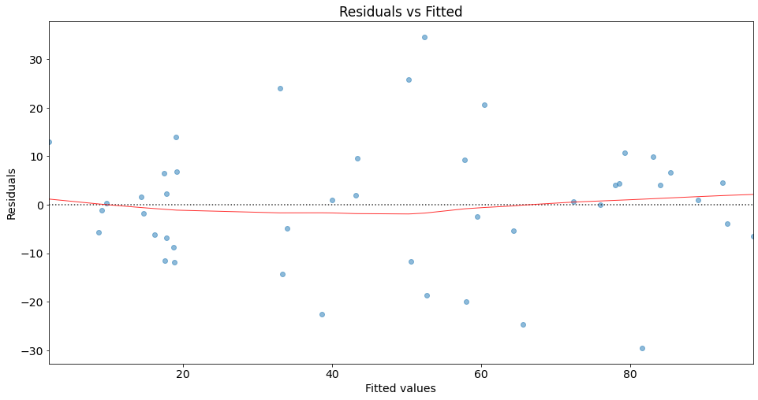

```python
# fitted values
model_fitted_y = lm.fittedvalues

#  Plot
plot = sns.residplot(x=model_fitted_y, y='prestige', data=df, lowess=True,
                     scatter_kws={'alpha': 0.5},
                     line_kws={'color': 'red', 'lw': 1, 'alpha': 0.8})

# Titel and labels
plot.set_title('Residuals vs Fitted')
plot.set_xlabel('Fitted values')
plot.set_ylabel('Residuals');
```

### Breusch-Pagan Lagrange Multiplier test

> The Breusch-Pagan Lagrange Multiplier test can be used to identify heteroscedasticity.

The test assumes homoscedasticity (this is the null hypothesis $H_0$) which means that the residual variance does not depend on the values of the variables in x.

If one of the test statistics is significant (i.e., p <= 0.05), then you have indication of heteroscedasticity.

```python
name = ['Lagrange multiplier statistic', 'p-value', 'f-value', 'f p-value']
test = sm.stats.het_breuschpagan(lm.resid, lm.model.exog)
lzip(name, test)
```

```
[('Lagrange multiplier statistic', 0.5752191351127306),
 ('p-value', 0.7500543806429694),
 ('f-value', 0.27191134322318933),
 ('f p-value', 0.7632527707017838)]
```

In our case, both p-values are above 0.05, which means we can accept the null hypothesis. Therefore, we have an indication of homoscedasticity.

### Single Variable Regression Diagnostics

It gives a 2x2 plot containing the:

1. dependent variable and fitted values with prediction confidence intervals vs. the independent variable chosen,
2. the residuals of the model vs. the chosen independent variable,
3. a partial regression plot, and a
4. CCPR plot.

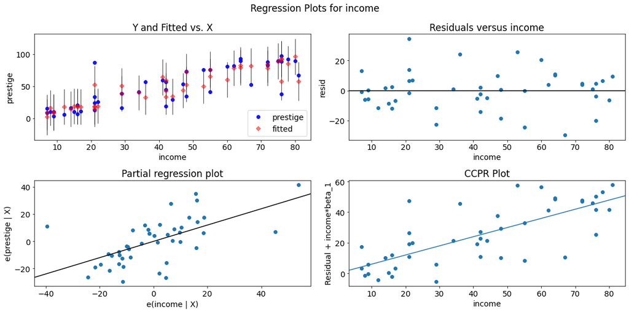

```python
fig = sm.graphics.plot_regress_exog(lm, "income")
fig.tight_layout(pad=1.0)
```

### Solutions

If we are faced with non-linear relationships between the dependent and independent variables, we can adjust the linear model via different methods (for more details, [see {cite:t}`Kuhn2019`](http://www.feat.engineering/numeric-one-to-many.html)):

- Basis expansions (polynomial features)
- Regression splines (especially natural cubic splines)
- Locally weighted scatterplot smoothing (loess)
- Generalized additive models (GAMs)

In particular, GAMs extend general linear models to have nonlinear terms for individual predictors. GAM models can adaptively model separate basis functions for different variables and estimate the complexity for each. In other words, different predictors can be modeled with different levels of complexity {cite:p}`Kuhn2019`.

In case of heteroscedasticity, you have the following options to get realsitic estimates of the standard errors:

- Use heteroskedasticity-consistent standard error estimators for OLS regression (see [statsmodels](https://www.statsmodels.org/dev/generated/statsmodels.regression.linear_model.OLSResults.get_robustcov_results.html)
- Use weight least squares (see [statsmodels](https://www.statsmodels.org/dev/examples/notebooks/generated/wls.html))

## Non-normally distributed errors

### Jarque-Bera test

The null hypothesis ($H_0$) is a joint hypothesis of:

1. the skewness being zero and
2. the kurtosis being 3.

```python
name = ['Jarque-Bera', 'Chi^2 two-tail prob.', 'Skew', 'Kurtosis']
test = sm.stats.jarque_bera(lm.resid)

lzip(name, test)
```

```
[('Jarque-Bera', 0.5195278349686433),
 ('Chi^2 two-tail prob.', 0.7712336390906139),
 ('Skew', 0.1549318677987544),
 ('Kurtosis', 3.425518480614924)]
```

The p-value is above 0.05 and we can accept $H_0$. Therefore, the test gives us an indication that the errors are normally distributed.

### Omnibus normtest

Our null hypothesis ($H_0$) is that the residuals are from a normal distribution.

```python
name = ['Chi^2', 'Two-tail probability']
test = sm.stats.omni_normtest(lm.resid)
lzip(name, test)
```

```
[('Chi^2', 1.2788071145675917), ('Two-tail probability', 0.5276070175778638)]
```

The p-value is above 0.05 and we can accept $H_0$. Therefore, the test gives us an indication that the errors are from a normal distribution.

## Correlation of error terms

### Durbin-Watson test

> A small p-value indicates there is significant autocorrelation remaining in the residuals.

If there is no autocorrelation, the Durbin-Watson distribution is symmetric around 2.

As a rough rule of thumb {cite:p}`Field2013`:

- If Durbin–Watson is less than 1.0, there may be cause for concern.
- Small values of d indicate successive error terms are positively correlated.
- If d > 2, successive error terms are negatively correlated.

```python
sm.stats.durbin_watson(lm.resid)
```

```
1.458332862235202
```

## Collinearity

### Correlation matrix

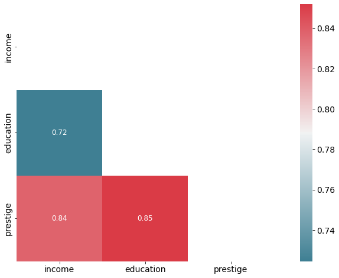

```python
# Inspect correlation
# Calculate correlation using the default method ( "pearson")
corr = df.corr()
# optimize aesthetics: generate mask for removing duplicate / unnecessary info
mask = np.zeros_like(corr, dtype=bool)
mask[np.triu_indices_from(mask)] = True
# Generate a custom diverging colormap as indicator for correlations:
cmap = sns.diverging_palette(220, 10, as_cmap=True)
# Plot
sns.heatmap(corr, mask=mask, cmap=cmap, annot=True,  square=True, annot_kws={"size": 12});
```

### Variance inflation factor (VIF)

- The smallest possible value for VIF is 1, which indicates the complete absence of collinearity.
- Typically in practice there is a small amount of collinearity among the predictors.
- As a rule of thumb, a VIF value that exceeds 5 indicates a problematic amount of collinearity and the parameter estimates will have large standard errors because of this.

```python
y, X = dmatrices('prestige ~ income + education', df, return_type='dataframe')

# For each X, calculate VIF and save in dataframe
vif = pd.DataFrame()
vif["VIF Factor"] = [variance_inflation_factor(X.values, i) for i in range(X.shape[1])]
vif["Feature"] = X.columns

vif.round(2)
```

|  | VIF Factor | Feature |
| --- | --- | --- |
| 0 | 4.59 | Intercept |
| 1 | 2.10 | income |
| 2 | 2.10 | education |